# Exploring harmful effects of weather events

Jón Guttesen

5 mai 2017

## Synopsis

The U.S. National Oceanic and Atmospheric Administration’s (NOAA) storm database tracks characteristics of major storms and weather events in the United States, including when and where they occur, as well as estimates of any fatalities, injuries, and property damage.

This project is an analasys of the harmfulness of each type of weather event measured in human fatalities or injures and damage to crops and property.

## Data processing

The folowing code loads libraries and reads data.

```r
knitr::opts_chunk$set(echo = TRUE, cache = TRUE )

# Load the required libraries
library(ggplot2)
library(lubridate)
library(stringdist)

# Read the data. The data file must be stored in the current working directory.
repfilename = "repdata_data_StormData.csv.bz2"
repdatafile <- bzfile(repfilename, open = "r")
repdata <- read.csv(repdatafile, header = TRUE, strip.white = TRUE, stringsAsFactors = FALSE )
```

```r
knitr::opts_chunk$set(echo = TRUE, cache = TRUE )

# Format the begin date column
repdata$BGN_DATEdate <- as.Date(as.character(repdata$BGN_DATE), format = "%m/%d/%Y")

# Exclude rows before 1996
repdata <- repdata[(repdata$BGN_DATEdate >= 1996),]

# Select only pertinent columns
repdata <- repdata[,c('EVTYPE','FATALITIES','INJURIES', 'PROPDMG', 'PROPDMGEXP', 'CROPDMG', 'CROPDMGEXP')]

# Try to assign a standard event type.

STD_EVENT_TYPES= toupper(c("Astronomical Low Tide","Avalanche","Blizzard", "Coastal Flood", "Cold/Wind Chill", "Debris Flow", "Dense Fog", "Dense Smoke", "Drought", "Dust Devil", "Dust Storm", "Excessive Heat", "Extreme Cold/Wind Chill", "Flash Flood", "Flood", "Frost/Freeze", "Funnel Cloud", "Freezing Fog", "Hail", "Heat", "Heavy Rain", "Heavy Snow", "High Surf", "High Wind", "Hurricane (Typhoon)", "Ice Storm","Lake-Effect Snow","Lakeshore Flood","Lightning","Marine Hail","Marine High Wind","Marine Strong Wind","Marine Thunderstorm Wind","Rip Current","Seiche","Sleet","Storm Surge/Tide","Strong Wind","Thunderstorm Wind","Tornado","Tropical Depression","Tropical Storm","Tsunami","Volcanic Ash","Waterspout","Wildfire","Winter Storm","Winter Weather"))

# Format evtype column
repdata$EVTYPE <- toupper(repdata$EVTYPE)

# Use amatch "Levenstein" method to group EVTYPE into the 48 standard EV types.
repdata$EVTYPE1 <- STD_EVENT_TYPES[amatch(repdata$EVTYPE, STD_EVENT_TYPES, maxDist = 10, method = "lv")]

# report success factor
mean( is.na( amatch(repdata$EVTYPE, STD_EVENT_TYPES, maxDist = 10, method = "lv")))
```

```
## [1] 0.005278189
```

```r
repdata$EVTYPE1  <- as.factor(repdata$EVTYPE1)

# Format the propery and crop damage exponent fields
repdata$PROPDMGEXP <- toupper(repdata$PROPDMGEXP)
repdata$CROPDMGEXP <- toupper(repdata$CROPDMGEXP)

repdata$CROPDMG1 <- 0
repdata[repdata$CROPDMGEXP == "1", ]$CROPDMG1 <-repdata[repdata$CROPDMGEXP == "1", ]$CROPDMG * 10^1
repdata[repdata$CROPDMGEXP == "2", ]$CROPDMG1 <-repdata[repdata$CROPDMGEXP == "2", ]$CROPDMG * 10^2
repdata[repdata$CROPDMGEXP == "3", ]$CROPDMG1 <-repdata[repdata$CROPDMGEXP == "3", ]$CROPDMG * 10^3
repdata[repdata$CROPDMGEXP == "4", ]$CROPDMG1 <-repdata[repdata$CROPDMGEXP == "4", ]$CROPDMG * 10^4
repdata[repdata$CROPDMGEXP == "5", ]$CROPDMG1 <-repdata[repdata$CROPDMGEXP == "5", ]$CROPDMG * 10^5
repdata[repdata$CROPDMGEXP == "6", ]$CROPDMG1 <-repdata[repdata$CROPDMGEXP == "6", ]$CROPDMG * 10^6
repdata[repdata$CROPDMGEXP == "7", ]$CROPDMG1 <-repdata[repdata$CROPDMGEXP == "7", ]$CROPDMG * 10^7
repdata[repdata$CROPDMGEXP == "8", ]$CROPDMG1 <-repdata[repdata$CROPDMGEXP == "8", ]$CROPDMG * 10^8
repdata[repdata$CROPDMGEXP == "9", ]$CROPDMG1 <-repdata[repdata$CROPDMGEXP == "9", ]$CROPDMG * 10^9
repdata[repdata$CROPDMGEXP == "H", ]$CROPDMG1 <-repdata[repdata$CROPDMGEXP == "H", ]$CROPDMG * 10^2
repdata[repdata$CROPDMGEXP == "K", ]$CROPDMG1 <-repdata[repdata$CROPDMGEXP == "K", ]$CROPDMG * 10^3
repdata[repdata$CROPDMGEXP == "M", ]$CROPDMG1 <-repdata[repdata$CROPDMGEXP == "M", ]$CROPDMG * 10^6
repdata[repdata$CROPDMGEXP == "B", ]$CROPDMG1 <-repdata[repdata$CROPDMGEXP == "B", ]$CROPDMG * 10^9

repdata$PROPDMG1 <- 0
repdata[repdata$PROPDMGEXP == "1", ]$PROPDMG1 <-repdata[repdata$PROPDMGEXP == "1", ]$PROPDMG * 10^1
repdata[repdata$PROPDMGEXP == "2", ]$PROPDMG1 <-repdata[repdata$PROPDMGEXP == "2", ]$PROPDMG * 10^2
repdata[repdata$PROPDMGEXP == "3", ]$PROPDMG1 <-repdata[repdata$PROPDMGEXP == "3", ]$PROPDMG * 10^3
repdata[repdata$PROPDMGEXP == "4", ]$PROPDMG1 <-repdata[repdata$PROPDMGEXP == "4", ]$PROPDMG * 10^4
repdata[repdata$PROPDMGEXP == "5", ]$PROPDMG1 <-repdata[repdata$PROPDMGEXP == "5", ]$PROPDMG * 10^5
repdata[repdata$PROPDMGEXP == "6", ]$PROPDMG1 <-repdata[repdata$PROPDMGEXP == "6", ]$PROPDMG * 10^6
repdata[repdata$PROPDMGEXP == "7", ]$PROPDMG1 <-repdata[repdata$PROPDMGEXP == "7", ]$PROPDMG * 10^7
repdata[repdata$PROPDMGEXP == "8", ]$PROPDMG1 <-repdata[repdata$PROPDMGEXP == "8", ]$PROPDMG * 10^8
repdata[repdata$PROPDMGEXP == "9", ]$PROPDMG1 <-repdata[repdata$PROPDMGEXP == "9", ]$PROPDMG * 10^9
repdata[repdata$PROPDMGEXP == "H", ]$PROPDMG1 <-repdata[repdata$PROPDMGEXP == "H", ]$PROPDMG * 10^2
repdata[repdata$PROPDMGEXP == "K", ]$PROPDMG1 <-repdata[repdata$PROPDMGEXP == "K", ]$PROPDMG * 10^3
repdata[repdata$PROPDMGEXP == "M", ]$PROPDMG1 <-repdata[repdata$PROPDMGEXP == "M", ]$PROPDMG * 10^6
repdata[repdata$PROPDMGEXP == "B", ]$PROPDMG1 <-repdata[repdata$PROPDMGEXP == "B", ]$PROPDMG * 10^9

repdata$TOTALDMG <- repdata$CROPDMG1 + repdata$PROPDMG1
```

## Results

Summarize and plot fatalities by standard weather events and the same for injuries.

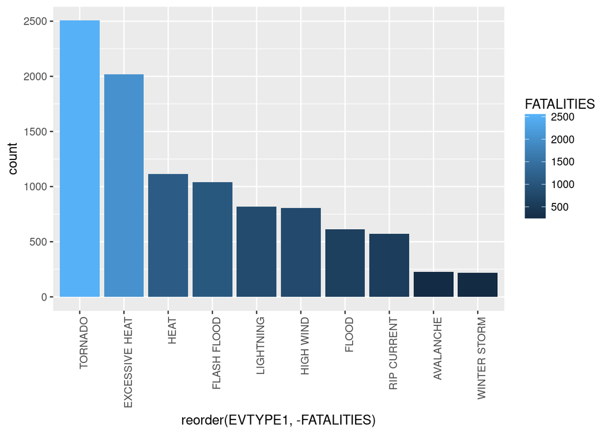

```r
knitr::opts_chunk$set(echo = TRUE, cache = TRUE )

repdatafatal <- aggregate( FATALITIES ~ EVTYPE1, repdata, sum )
repdatafatal <- repdatafatal[order(repdatafatal$FATALITIES, decreasing = TRUE),]
repdatafatal <- repdatafatal[((repdatafatal$FATALITIES) > 0),]

#ggplot(repdatafatal, aes(x=head(reorder(EVTYPE1,-FATALITIES),10), weight=FATALITIES, fill=FATALITIES)) + geom_bar()

ggplot(head(repdatafatal,10), aes(x=reorder(EVTYPE1,-FATALITIES), weight=FATALITIES, fill=FATALITIES)) + geom_bar() + theme(axis.text.x = element_text(angle = 90, hjust = 1))
```

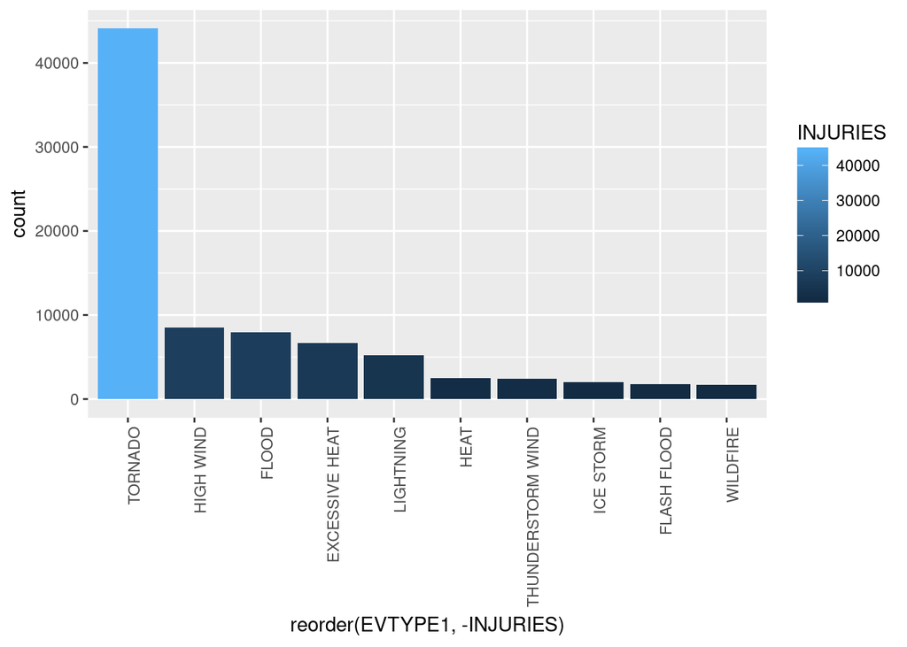

```r
repdatainj <- aggregate( INJURIES ~ EVTYPE1, repdata, sum )
repdatainj <- repdatainj[order(repdatainj$INJURIES, decreasing = TRUE),]
repdatainj <- repdatainj[((repdatainj$INJURIES) > 0),]

ggplot(head(repdatainj,10), aes(x=reorder(EVTYPE1,-INJURIES), weight=INJURIES, fill=INJURIES)) + geom_bar() + theme(axis.text.x = element_text(angle = 90, hjust = 1))
```

Summarize and plot damages to property and crops.

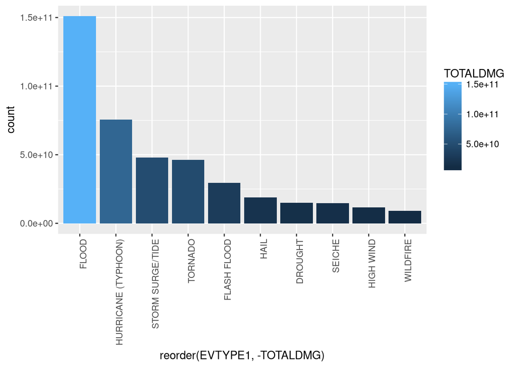

```r
  knitr::opts_chunk$set(echo = TRUE, cache = TRUE )

repdatadmg <- aggregate( TOTALDMG ~ EVTYPE1, repdata, sum )
repdatadmg <- repdatadmg[order(repdatadmg$TOTALDMG, decreasing = TRUE),]
#repdatadmg <- repdatadmg[((repdatadmg$INJURIES) > 0),]

ggplot(head(repdatadmg,10), aes(x=reorder(EVTYPE1,-TOTALDMG), weight=TOTALDMG, fill=TOTALDMG)) + geom_bar() + theme(axis.text.x = element_text(angle = 90, hjust = 1))
```